# Indicator Evaluation

#### Computational Investing Chris Harris 11 Nov 2014

## Introduction

#### Beyond price action, a second initiative builds on indicator development, with a goal to use indicator signals as a means to drive quantitative investment decisions. Although one could envision indicator values as triggers to buy or sell stocks, by modifying *event.py*, in the *quantitative analysis* routine, only the indicators themselves will receive attention here. When considering momentum signals, the commodity channel index, CCI, will serve as a baseline. To flatten or linearize bollinger bands: *bollinger feature = ( price - mean ) / standard deviation* yields a normalized, unitless quantity, a number of standard deviations above or below the mean. By producing a value relative to key reference areas: +2 standard deviations, mean, -2 standard deviations, it captures the behavior of bollinger bands. With the remarkable shape conformation between the bollinger feature and CCI, the bollinger bands depict a 2-D graphical illustration of momentum. When the bollinger bands contract to a narrow range, momentum indicator noise becomes apparent, as the weak bandwidth amplifies superficial momentum shifts. Although John Bollinger promotes a 20 period moving average as a reference frame, a 40 period momentum profile dwells primarily above zero in an uptrend, and below zero in a downtrend. Conventional scientific techniques suggest a 40 sample population count represents a minimum threshold to ensure statistical significance. Hence, statistical knowledge may explain why institutional investors recognize the 50 period moving average as the boundary between buy and sell. A notable departure from this guideline includes the relative strength index, RSI, where a 14 period momentum value corresponds to a 40 period CCI. When comparing performance, put the indicators side by side to observe response times.

## Python Code

```
cci.py:

import os
import shutil
import math
import matplotlib as mpl
import matplotlib.pyplot as plt

# obtain market data
def acquire(sym,interval):

    if not os.path.isfile("../data/%s.csv" %sym):
        shutil.copy("../QSTK-0.2.8/QSTK/QSData/Yahoo/%s.csv" %sym, "../data")
    data   = open("../data/%s.csv" %sym,'r')
    stream = data.read()
    data.close()

    field  = 7
    entry  = ""
    val    = []
    matrix = []

    for ch in stream:
        entry = entry + ch
        if ch==',' or ch=='\n':
            if len(entry)>1:
                val.append(entry[:-1])
            entry = ""
        if len(val)>=field:
            if interval[1] >= val[0] >= interval[0]:
                matrix.append(val)
            val = []

    matrix.sort()
    return matrix

def plot(label,matrix,mean,cci,delta,period):

    x = []
    y = [[]for l in range(2)]
```

[output cut: 80 more lines]

```

    # display results
    print("\n  # %i-period lookback cycles =\t%i\n" %(delta,period-delta))
    plot(symbol,matrix,mean,cci,delta,period)
    return cci

def main():

    delta    = 20
    symbol   = "GOOGL"
    interval = ["2007-12-04","2009-12-31"]

    cf = cci(symbol,delta,interval)

main()
```

## Python Code

```
bollinger.py:

import os
import shutil
import math
import matplotlib as mpl
import matplotlib.pyplot as plt

# obtain market data
def acquire(sym,interval):

    if not os.path.isfile("../data/%s.csv" %sym):
        shutil.copy("../QSTK-0.2.8/QSTK/QSData/Yahoo/%s.csv" %sym, "../data")
    data   = open("../data/%s.csv" %sym,'r')
    stream = data.read()
    data.close()

    field  = 7
    entry  = ""
    val    = []
    matrix = []

    for ch in stream:
        entry = entry + ch
        if ch==',' or ch=='\n':
            if len(entry)>1:
                val.append(entry[:-1])
            entry = ""
        if len(val)>=field:
            if interval[1] >= val[0] >= interval[0]:
                matrix.append(val)
            val = []

    matrix.sort()
    return matrix

def plot(label,matrix,mean,std,rat,delta,period):

    x  = []
    y  = [[]for l in range(4)]
```

[output cut: 70 more lines]

```

    # display results
    print("\n  # %i-period lookback cycles =\t%i\n" %(delta,period-delta))
    plot(symbol,matrix,mean,std,rat,delta,period)
    return rat

def main():

    delta    = 20
    symbol   = "GOOGL"
    interval = ["2007-12-04","2009-12-31"]

    bf = bollinger(symbol,delta,interval)

main()
```

## PowerLanguage .NET Code

#### Multichart bollinger feature with trailing 6 period moving average

```
Bollinger_Ratio_Triangle.pln:

using System;
using System.Drawing;
using PowerLanguage.Function;

namespace PowerLanguage.Indicator
{
    [SameAsSymbol(true)]
    public class Bollinger_Ratio_Triangle : IndicatorObject
    {
        private TriAverage m_triaverage1;
        private TriAverage m_triaverage2;
        private VariableSeries<Double> ratio;
        private Function.NormGradientColor m_normgradientcolor1;
        private int m_applicationtype;
        private IPlotObject Plot1;
        private IPlotObject Plot2;
        private IPlotObject Plot3;
        private IPlotObject Plot4;
        private IPlotObject Plot5;

        public Bollinger_Ratio_Triangle(object ctx) :
            base(ctx){
            axis      =  0;
            numdevsdn = -2;
            numdevsup =  2;
            avelength =  6;
            bollength = 20;
            gridforegroundcolor = Color.Black;
            dncolor = Color.Red;
            upcolor = Color.Yellow;
            colornormlength = 14;
        }

        private ISeries<double> bollingerprice { get; set; }

        [Input]
        public int avelength { get; set; }

```

[output cut: 60 more lines]

```
            if (!upcolor.IsEmpty && !dncolor.IsEmpty){
                var m_colorlevel = m_normgradientcolor1.Value;
                if (m_applicationtype == 1){
                    Plot5.Colors[0] = m_colorlevel;
                }
                else{
                    if (m_applicationtype > 1){
                        Plot5.Colors[0] = gridforegroundcolor;
                        Plot5.BGColor = m_colorlevel;
                    }
                }
            }
        }
    }
}
```

## Results

```
$ python cci.py

           Date                Index            Price           Mean            AbDev           CCI

        2008-01-02              19              342.94          348.1           5.419           -53.97
        2008-01-03              20              343.01          348.1           5.457           -76.75
        2008-01-04              21              328.83          347.3           6.251           -158
        2008-01-07              22              324.95          345.8           7.813           -176.4
        2008-01-08              23              316.16          344             8.949           -172.8
        2008-01-09              24              326.93          342.1           9.924           -135.9
        2008-01-10              25              323.69          340.6           9.773           -111
        2008-01-11              26              319.44          339.1           10.1            -126.1
        2008-01-14              27              327.24          338.1           10.19           -76.45
        2008-01-15              28              319.14          336.8           10.54           -102.1
                                                                 ...
        2009-12-17              514             297.27          293.4           3.038           97.45
        2009-12-18              515             298.51          294             3.052           101.9
        2009-12-21              516             299.64          294.7           2.43            126.4
        2009-12-22              517             300.86          295.2           2.591           137.7
        2009-12-23              518             306.15          295.9           3.08            194.4
        2009-12-24              519             309.55          296.7           4.065           196.9
        2009-12-28              520             311.75          297.8           5.569           164.4
        2009-12-29              521             310.01          298.8           6.139           129.7
        2009-12-30              522             311.68          299.6           6.174           121.7
        2009-12-31              523             310.30          300.4           6.248           114.8

  # 20-period lookback cycles = 504

$ python bollinger.py

           Date                Index            Price           Mean            StDev           Feature

        2008-01-02              19              342.94          348.1           6.618           -0.7855
        2008-01-03              20              343.01          348.2           6.594           -0.7823
        2008-01-04              21              328.83          347.1           7.81            -2.343
        2008-01-07              22              324.95          345.5           8.773           -2.34
        2008-01-08              23              316.16          343.4           10.39           -2.62
        2008-01-09              24              326.93          341.8           10.29           -1.442
        2008-01-10              25              323.69          340.5           10.82           -1.549
        2008-01-11              26              319.44          338.9           11.5            -1.694
```

[output cut: 56 more lines]

[output not shown]

#### **Figure 1**: GOOGL Stockchart; day, 20 period cci

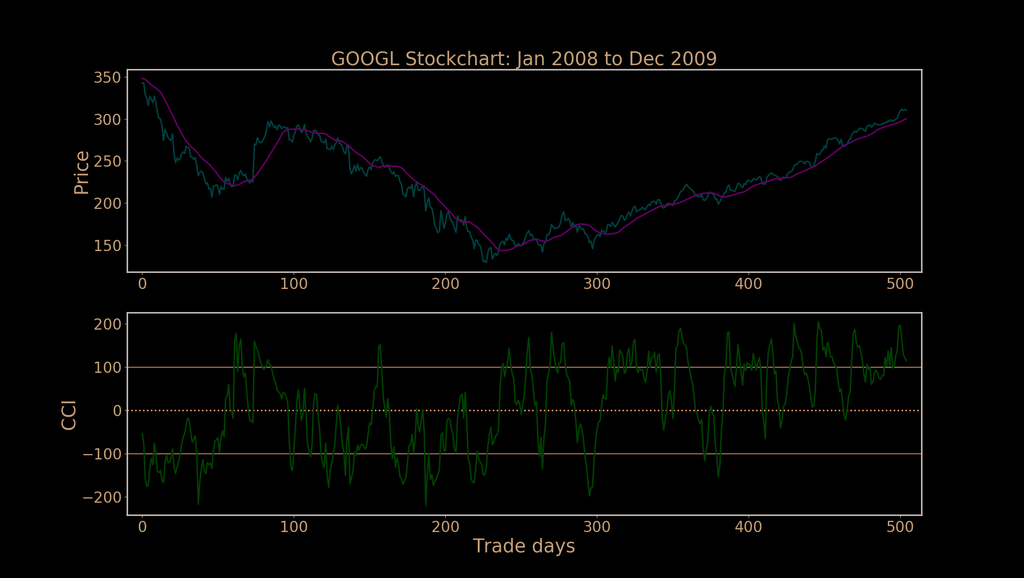

#### **Figure 2**: GOOGL Stockchart; day, 20 period bf

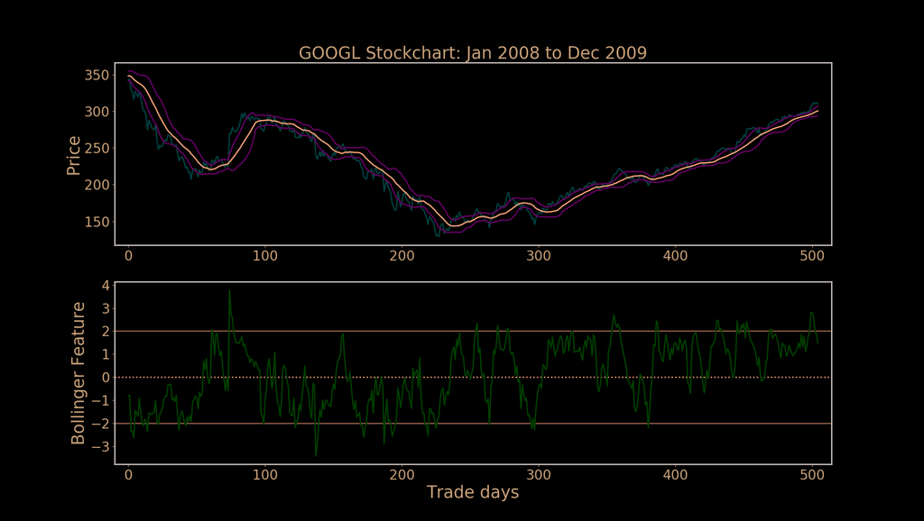

#### **Figure 3**: GOOGL Stockchart; day, 40 period cci

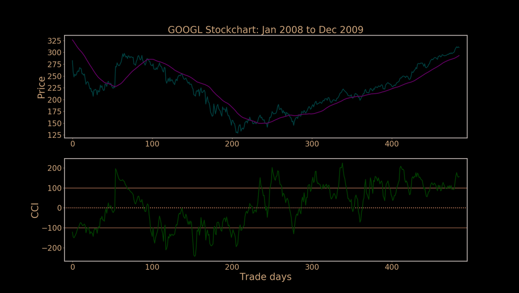

#### **Figure 4**: GOOGL Stockchart; day, 40 period bf

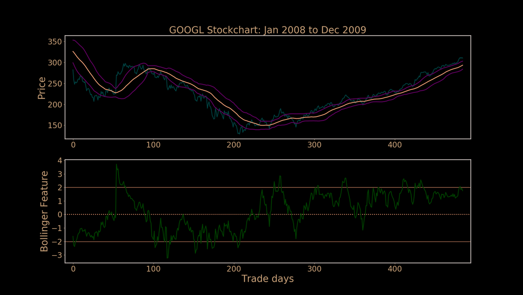

#### **Figure 5**: YM Future Chart; 30 min, 20 period bf

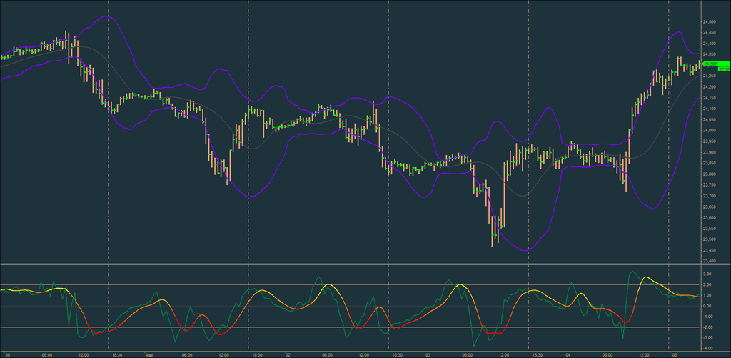

#### **Figure 6**: YM Future Chart; 30 min, 40 period bf

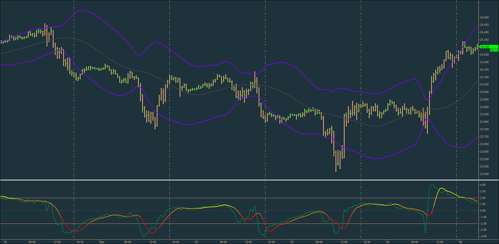

#### **Figure 7**: YM Future Chart; 4096 tick, 20 period bf

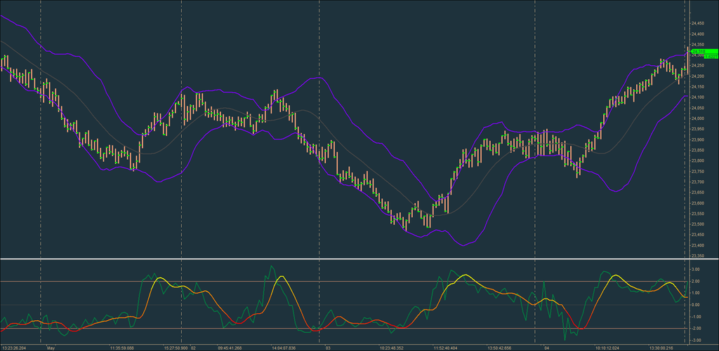

#### **Figure 8**: YM Future Chart; 4096 tick, 40 period bf

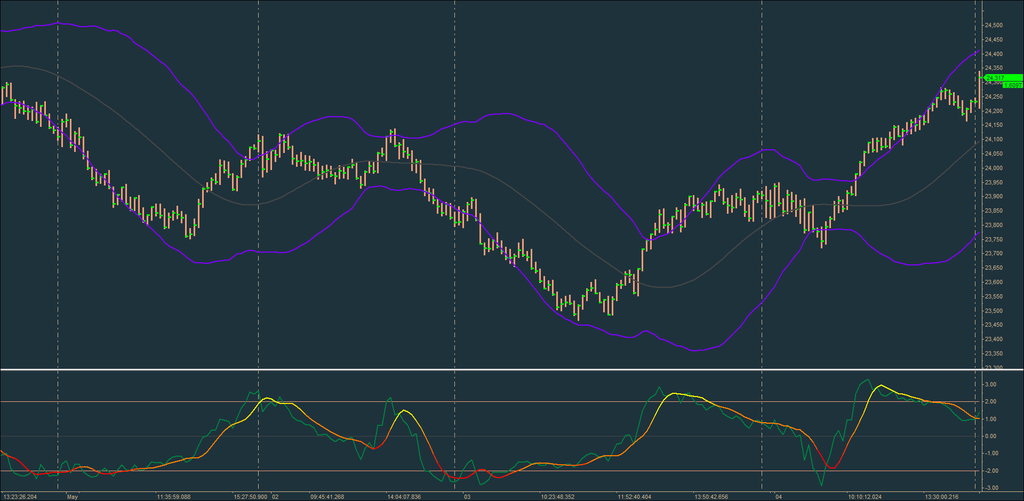